# Risk Factor Analysis

## Outcome Variable

**Outcome Variable:** wasted

## Predictor Variables

**Intervention Variable:** exclfeed36

**Adjustment Set:**

unadjusted

## Stratifying Variables

The analysis was stratified on these variable(s):

- agecat
- studyid
- country

## Data Summary

| agecat | studyid | country | exclfeed36 | wasted | n_cell | n | outcome_variable |
| --- | --- | --- | --- | --- | --- | --- | --- |
| Birth | ki0047075b-MAL-ED | BANGLADESH | 1 | 0 | 27 | 208 | wasted |
| Birth | ki0047075b-MAL-ED | BANGLADESH | 1 | 1 | 4 | 208 | wasted |
| Birth | ki0047075b-MAL-ED | BANGLADESH | 0 | 0 | 147 | 208 | wasted |
| Birth | ki0047075b-MAL-ED | BANGLADESH | 0 | 1 | 30 | 208 | wasted |
| Birth | ki0047075b-MAL-ED | BRAZIL | 1 | 0 | 4 | 62 | wasted |
| Birth | ki0047075b-MAL-ED | BRAZIL | 1 | 1 | 0 | 62 | wasted |
| Birth | ki0047075b-MAL-ED | BRAZIL | 0 | 0 | 56 | 62 | wasted |
| Birth | ki0047075b-MAL-ED | BRAZIL | 0 | 1 | 2 | 62 | wasted |
| Birth | ki0047075b-MAL-ED | INDIA | 1 | 0 | 1 | 40 | wasted |
| Birth | ki0047075b-MAL-ED | INDIA | 1 | 1 | 0 | 40 | wasted |
| Birth | ki0047075b-MAL-ED | INDIA | 0 | 0 | 34 | 40 | wasted |
| Birth | ki0047075b-MAL-ED | INDIA | 0 | 1 | 5 | 40 | wasted |
| Birth | ki0047075b-MAL-ED | NEPAL | 1 | 0 | 0 | 25 | wasted |
| Birth | ki0047075b-MAL-ED | NEPAL | 1 | 1 | 0 | 25 | wasted |
| Birth | ki0047075b-MAL-ED | NEPAL | 0 | 0 | 23 | 25 | wasted |
| Birth | ki0047075b-MAL-ED | NEPAL | 0 | 1 | 2 | 25 | wasted |
| Birth | ki0047075b-MAL-ED | PERU | 1 | 0 | 5 | 218 | wasted |
| Birth | ki0047075b-MAL-ED | PERU | 1 | 1 | 0 | 218 | wasted |
| Birth | ki0047075b-MAL-ED | PERU | 0 | 0 | 208 | 218 | wasted |
| Birth | ki0047075b-MAL-ED | PERU | 0 | 1 | 5 | 218 | wasted |
| Birth | ki0047075b-MAL-ED | SOUTH AFRICA | 1 | 0 | 1 | 104 | wasted |
| Birth | ki0047075b-MAL-ED | SOUTH AFRICA | 1 | 1 | 0 | 104 | wasted |
| Birth | ki0047075b-MAL-ED | SOUTH AFRICA | 0 | 0 | 94 | 104 | wasted |
| Birth | ki0047075b-MAL-ED | SOUTH AFRICA | 0 | 1 | 9 | 104 | wasted |
| Birth | ki0047075b-MAL-ED | TANZANIA, UNITED REPUBLIC OF | 1 | 0 | 0 | 111 | wasted |
| Birth | ki0047075b-MAL-ED | TANZANIA, UNITED REPUBLIC OF | 1 | 1 | 0 | 111 | wasted |
| Birth | ki0047075b-MAL-ED | TANZANIA, UNITED REPUBLIC OF | 0 | 0 | 110 | 111 | wasted |
| Birth | ki0047075b-MAL-ED | TANZANIA, UNITED REPUBLIC OF | 0 | 1 | 1 | 111 | wasted |
| Birth | ki1000108-CMC-V-BCS-2002 | INDIA | 1 | 0 | 3 | 3 | wasted |
| Birth | ki1000108-CMC-V-BCS-2002 | INDIA | 1 | 1 | 0 | 3 | wasted |

[output cut: 162 more lines]

The following strata were considered:

- agecat: 24 months, studyid: ki0047075b-MAL-ED, country: BANGLADESH
- agecat: 24 months, studyid: ki0047075b-MAL-ED, country: BRAZIL
- agecat: 24 months, studyid: ki0047075b-MAL-ED, country: INDIA
- agecat: 24 months, studyid: ki0047075b-MAL-ED, country: NEPAL
- agecat: 24 months, studyid: ki0047075b-MAL-ED, country: PERU
- agecat: 24 months, studyid: ki0047075b-MAL-ED, country: SOUTH AFRICA
- agecat: 24 months, studyid: ki0047075b-MAL-ED, country: TANZANIA, UNITED REPUBLIC OF
- agecat: 24 months, studyid: ki1000108-CMC-V-BCS-2002, country: INDIA
- agecat: 24 months, studyid: ki1000108-IRC, country: INDIA
- agecat: 24 months, studyid: ki1000109-EE, country: PAKISTAN
- agecat: 24 months, studyid: ki1017093b-PROVIDE, country: BANGLADESH
- agecat: 24 months, studyid: ki1101329-Keneba, country: GAMBIA
- agecat: 24 months, studyid: ki1113344-GMS-Nepal, country: NEPAL
- agecat: 24 months, studyid: ki1148112-LCNI-5, country: MALAWI
- agecat: 24 months, studyid: kiGH5241-JiVitA-3, country: BANGLADESH
- agecat: 24 months, studyid: kiGH5241-JiVitA-4, country: BANGLADESH
- agecat: 6 months, studyid: ki0047075b-MAL-ED, country: BANGLADESH
- agecat: 6 months, studyid: ki0047075b-MAL-ED, country: BRAZIL
- agecat: 6 months, studyid: ki0047075b-MAL-ED, country: INDIA
- agecat: 6 months, studyid: ki0047075b-MAL-ED, country: NEPAL
- agecat: 6 months, studyid: ki0047075b-MAL-ED, country: PERU
- agecat: 6 months, studyid: ki0047075b-MAL-ED, country: SOUTH AFRICA
- agecat: 6 months, studyid: ki0047075b-MAL-ED, country: TANZANIA, UNITED REPUBLIC OF
- agecat: 6 months, studyid: ki1000108-CMC-V-BCS-2002, country: INDIA
- agecat: 6 months, studyid: ki1000108-IRC, country: INDIA
- agecat: 6 months, studyid: ki1000109-EE, country: PAKISTAN
- agecat: 6 months, studyid: ki1000304b-SAS-FoodSuppl, country: INDIA
- agecat: 6 months, studyid: ki1017093b-PROVIDE, country: BANGLADESH
- agecat: 6 months, studyid: ki1101329-Keneba, country: GAMBIA
- agecat: 6 months, studyid: ki1113344-GMS-Nepal, country: NEPAL
- agecat: 6 months, studyid: ki1148112-LCNI-5, country: MALAWI
- agecat: 6 months, studyid: kiGH5241-JiVitA-3, country: BANGLADESH
- agecat: 6 months, studyid: kiGH5241-JiVitA-4, country: BANGLADESH
- agecat: Birth, studyid: ki0047075b-MAL-ED, country: BANGLADESH
- agecat: Birth, studyid: ki0047075b-MAL-ED, country: BRAZIL
- agecat: Birth, studyid: ki0047075b-MAL-ED, country: INDIA
- agecat: Birth, studyid: ki0047075b-MAL-ED, country: NEPAL
- agecat: Birth, studyid: ki0047075b-MAL-ED, country: PERU
- agecat: Birth, studyid: ki0047075b-MAL-ED, country: SOUTH AFRICA
- agecat: Birth, studyid: ki0047075b-MAL-ED, country: TANZANIA, UNITED REPUBLIC OF
- agecat: Birth, studyid: ki1000108-CMC-V-BCS-2002, country: INDIA
- agecat: Birth, studyid: ki1000108-IRC, country: INDIA
- agecat: Birth, studyid: ki1000109-EE, country: PAKISTAN
- agecat: Birth, studyid: ki1017093b-PROVIDE, country: BANGLADESH
- agecat: Birth, studyid: ki1101329-Keneba, country: GAMBIA
- agecat: Birth, studyid: ki1113344-GMS-Nepal, country: NEPAL
- agecat: Birth, studyid: kiGH5241-JiVitA-3, country: BANGLADESH
- agecat: Birth, studyid: kiGH5241-JiVitA-4, country: BANGLADESH

### Dropped Strata

Some strata were dropped due to rare outcomes:

- agecat: Birth, studyid: ki0047075b-MAL-ED, country: BANGLADESH
- agecat: Birth, studyid: ki0047075b-MAL-ED, country: BRAZIL
- agecat: Birth, studyid: ki0047075b-MAL-ED, country: INDIA
- agecat: Birth, studyid: ki0047075b-MAL-ED, country: NEPAL
- agecat: Birth, studyid: ki0047075b-MAL-ED, country: PERU
- agecat: Birth, studyid: ki0047075b-MAL-ED, country: SOUTH AFRICA
- agecat: Birth, studyid: ki0047075b-MAL-ED, country: TANZANIA, UNITED REPUBLIC OF
- agecat: Birth, studyid: ki1000108-CMC-V-BCS-2002, country: INDIA
- agecat: Birth, studyid: ki1000108-IRC, country: INDIA
- agecat: Birth, studyid: ki1000109-EE, country: PAKISTAN
- agecat: 6 months, studyid: ki0047075b-MAL-ED, country: BANGLADESH
- agecat: 6 months, studyid: ki0047075b-MAL-ED, country: BRAZIL
- agecat: 6 months, studyid: ki0047075b-MAL-ED, country: INDIA
- agecat: 6 months, studyid: ki0047075b-MAL-ED, country: NEPAL
- agecat: 6 months, studyid: ki0047075b-MAL-ED, country: PERU
- agecat: 6 months, studyid: ki0047075b-MAL-ED, country: SOUTH AFRICA
- agecat: 6 months, studyid: ki0047075b-MAL-ED, country: TANZANIA, UNITED REPUBLIC OF
- agecat: 6 months, studyid: ki1000108-CMC-V-BCS-2002, country: INDIA
- agecat: 6 months, studyid: ki1000108-IRC, country: INDIA
- agecat: 6 months, studyid: ki1000109-EE, country: PAKISTAN
- agecat: 6 months, studyid: ki1000304b-SAS-FoodSuppl, country: INDIA
- agecat: 6 months, studyid: ki1017093b-PROVIDE, country: BANGLADESH
- agecat: 6 months, studyid: ki1148112-LCNI-5, country: MALAWI
- agecat: 24 months, studyid: ki0047075b-MAL-ED, country: BANGLADESH
- agecat: 24 months, studyid: ki0047075b-MAL-ED, country: BRAZIL
- agecat: 24 months, studyid: ki0047075b-MAL-ED, country: INDIA
- agecat: 24 months, studyid: ki0047075b-MAL-ED, country: NEPAL
- agecat: 24 months, studyid: ki0047075b-MAL-ED, country: PERU
- agecat: 24 months, studyid: ki0047075b-MAL-ED, country: SOUTH AFRICA
- agecat: 24 months, studyid: ki0047075b-MAL-ED, country: TANZANIA, UNITED REPUBLIC OF
- agecat: 24 months, studyid: ki1000108-CMC-V-BCS-2002, country: INDIA
- agecat: 24 months, studyid: ki1000108-IRC, country: INDIA
- agecat: 24 months, studyid: ki1000109-EE, country: PAKISTAN
- agecat: 24 months, studyid: ki1148112-LCNI-5, country: MALAWI

## Methods Detail

We’re interested in the causal parameters $E[Y_a]$ for all values of $a \in \mathcal{A}$. These parameters represent the mean outcome if, possibly contrary to fact, we intervened to set all units to have $A=a$. Under the randomization and positivity assumptions, these are identified by the statistical parameters $\psi_a=E_W[E_{Y|A,W}(Y|A=a,W)]$. In addition, we’re interested in the mean of $Y$, $E[Y]$ under no intervention (the observed mean). We will estimate these parameters by using SuperLearner to fit the relevant likelihood factors – $E_{Y|A,W}(Y|A=a,W)$ and $p(A=a|W)$, and then updating our likelihood fit using a joint TMLE.

For unadjusted analyses ($W=\{\}$), initial likelihoods were estimated using Lrnr_glm to estimate the simple $E(Y|A)$ and Lrnr_mean to estimate $p(A)$. For adjusted analyses, a small library containing Lrnr_glmnet, Lrnr_xgboost, and Lrnr_mean was used.

Having estimated these parameters, we will then use the delta method to estimate relative risks and attributable risks relative to a prespecified baseline level of $A$.

# Results Detail

## Results Plots

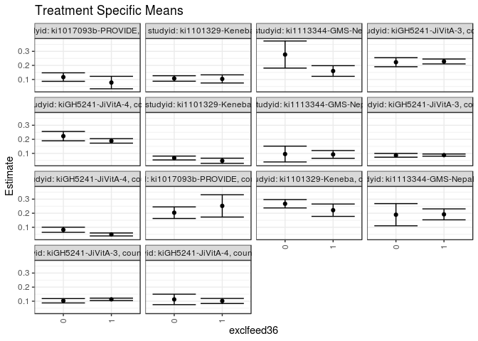

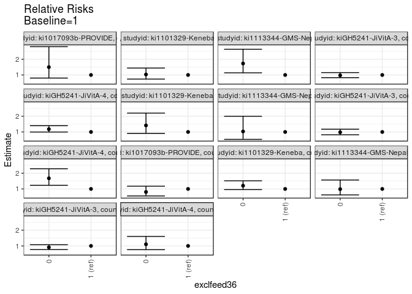

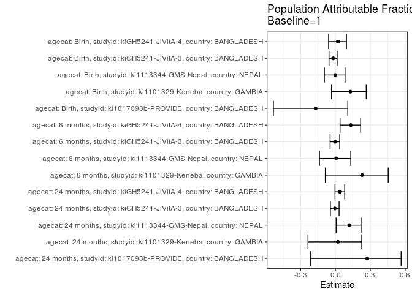

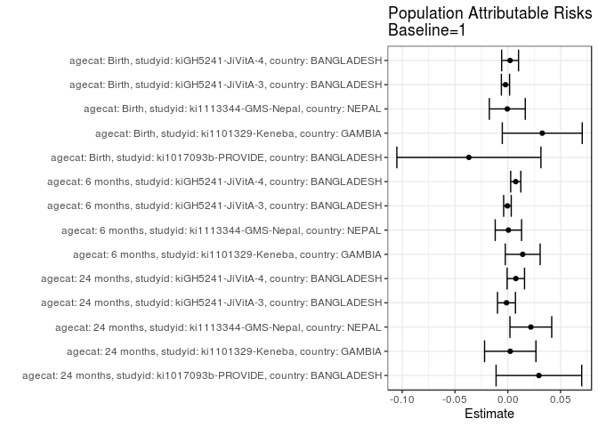

## Results Table

### Parameter: TSM

| agecat | studyid | country | intervention_level | baseline_level | estimate | ci_lower | ci_upper |
| --- | --- | --- | --- | --- | --- | --- | --- |
| Birth | ki1017093b-PROVIDE | BANGLADESH | 1 | NA | 0.2521739 | 0.1727229 | 0.3316250 |
| Birth | ki1017093b-PROVIDE | BANGLADESH | 0 | NA | 0.2038043 | 0.1626050 | 0.2450037 |
| Birth | ki1101329-Keneba | GAMBIA | 1 | NA | 0.2215743 | 0.1776048 | 0.2655438 |
| Birth | ki1101329-Keneba | GAMBIA | 0 | NA | 0.2673734 | 0.2375898 | 0.2971570 |
| Birth | ki1113344-GMS-Nepal | NEPAL | 1 | NA | 0.1919192 | 0.1530926 | 0.2307458 |
| Birth | ki1113344-GMS-Nepal | NEPAL | 0 | NA | 0.1894737 | 0.1105900 | 0.2683573 |
| Birth | kiGH5241-JiVitA-3 | BANGLADESH | 1 | NA | 0.1131235 | 0.1045284 | 0.1217186 |
| Birth | kiGH5241-JiVitA-3 | BANGLADESH | 0 | NA | 0.1030271 | 0.0874661 | 0.1185880 |
| Birth | kiGH5241-JiVitA-4 | BANGLADESH | 1 | NA | 0.1016949 | 0.0837341 | 0.1196558 |
| Birth | kiGH5241-JiVitA-4 | BANGLADESH | 0 | NA | 0.1127098 | 0.0754584 | 0.1499612 |
| 6 months | ki1101329-Keneba | GAMBIA | 1 | NA | 0.0473373 | 0.0288473 | 0.0658273 |
| 6 months | ki1101329-Keneba | GAMBIA | 0 | NA | 0.0670304 | 0.0533428 | 0.0807179 |
| 6 months | ki1113344-GMS-Nepal | NEPAL | 1 | NA | 0.0924171 | 0.0647589 | 0.1200752 |
| 6 months | ki1113344-GMS-Nepal | NEPAL | 0 | NA | 0.0952381 | 0.0390378 | 0.1514384 |
| 6 months | kiGH5241-JiVitA-3 | BANGLADESH | 1 | NA | 0.0876391 | 0.0798229 | 0.0954553 |
| 6 months | kiGH5241-JiVitA-3 | BANGLADESH | 0 | NA | 0.0861196 | 0.0727790 | 0.0994601 |
| 6 months | kiGH5241-JiVitA-4 | BANGLADESH | 1 | NA | 0.0490741 | 0.0385851 | 0.0595631 |
| 6 months | kiGH5241-JiVitA-4 | BANGLADESH | 0 | NA | 0.0822785 | 0.0640829 | 0.1004740 |
| 24 months | ki1017093b-PROVIDE | BANGLADESH | 1 | NA | 0.0780142 | 0.0337080 | 0.1223203 |
| 24 months | ki1017093b-PROVIDE | BANGLADESH | 0 | NA | 0.1169725 | 0.0867792 | 0.1471658 |
| 24 months | ki1101329-Keneba | GAMBIA | 1 | NA | 0.1037736 | 0.0747352 | 0.1328120 |
| 24 months | ki1101329-Keneba | GAMBIA | 0 | NA | 0.1071061 | 0.0876479 | 0.1265642 |
| 24 months | ki1113344-GMS-Nepal | NEPAL | 1 | NA | 0.1602210 | 0.1223920 | 0.1980500 |
| 24 months | ki1113344-GMS-Nepal | NEPAL | 0 | NA | 0.2771084 | 0.1807124 | 0.3735044 |
| 24 months | kiGH5241-JiVitA-3 | BANGLADESH | 1 | NA | 0.2280278 | 0.2106393 | 0.2454163 |
| 24 months | kiGH5241-JiVitA-3 | BANGLADESH | 0 | NA | 0.2226640 | 0.1904944 | 0.2548336 |
| 24 months | kiGH5241-JiVitA-4 | BANGLADESH | 1 | NA | 0.1886973 | 0.1726293 | 0.2047654 |
| 24 months | kiGH5241-JiVitA-4 | BANGLADESH | 0 | NA | 0.2225914 | 0.1894170 | 0.2557658 |

### Parameter: E(Y)

| agecat | studyid | country | intervention_level | baseline_level | estimate | ci_lower | ci_upper |
| --- | --- | --- | --- | --- | --- | --- | --- |
| Birth | ki1017093b-PROVIDE | BANGLADESH | NA | NA | 0.2153209 | 0.1786253 | 0.2520165 |
| Birth | ki1101329-Keneba | GAMBIA | NA | NA | 0.2541946 | 0.2294667 | 0.2789226 |
| Birth | ki1113344-GMS-Nepal | NEPAL | NA | NA | 0.1914460 | 0.1566101 | 0.2262820 |
| Birth | kiGH5241-JiVitA-3 | BANGLADESH | NA | NA | 0.1109177 | 0.1033745 | 0.1184610 |
| Birth | kiGH5241-JiVitA-4 | BANGLADESH | NA | NA | 0.1038534 | 0.0874500 | 0.1202568 |
| 6 months | ki1101329-Keneba | GAMBIA | NA | NA | 0.0614525 | 0.0503239 | 0.0725811 |
| 6 months | ki1113344-GMS-Nepal | NEPAL | NA | NA | 0.0929791 | 0.0681617 | 0.1177965 |
| 6 months | kiGH5241-JiVitA-3 | BANGLADESH | NA | NA | 0.0872876 | 0.0805483 | 0.0940269 |
| 6 months | kiGH5241-JiVitA-4 | BANGLADESH | NA | NA | 0.0565903 | 0.0475372 | 0.0656433 |
| 24 months | ki1017093b-PROVIDE | BANGLADESH | NA | NA | 0.1074523 | 0.0821617 | 0.1327430 |
| 24 months | ki1101329-Keneba | GAMBIA | NA | NA | 0.1060932 | 0.0899270 | 0.1222593 |
| 24 months | ki1113344-GMS-Nepal | NEPAL | NA | NA | 0.1820225 | 0.1461311 | 0.2179138 |
| 24 months | kiGH5241-JiVitA-3 | BANGLADESH | NA | NA | 0.2267779 | 0.2114523 | 0.2421034 |
| 24 months | kiGH5241-JiVitA-4 | BANGLADESH | NA | NA | 0.1962825 | 0.1816413 | 0.2109237 |

### Parameter: RR

| agecat | studyid | country | intervention_level | baseline_level | estimate | ci_lower | ci_upper |
| --- | --- | --- | --- | --- | --- | --- | --- |
| Birth | ki1017093b-PROVIDE | BANGLADESH | 1 | 1 | 1.0000000 | 1.0000000 | 1.000000 |
| Birth | ki1017093b-PROVIDE | BANGLADESH | 0 | 1 | 0.8081897 | 0.5558264 | 1.175134 |
| Birth | ki1101329-Keneba | GAMBIA | 1 | 1 | 1.0000000 | 1.0000000 | 1.000000 |
| Birth | ki1101329-Keneba | GAMBIA | 0 | 1 | 1.2066983 | 0.9610964 | 1.515062 |
| Birth | ki1113344-GMS-Nepal | NEPAL | 1 | 1 | 1.0000000 | 1.0000000 | 1.000000 |
| Birth | ki1113344-GMS-Nepal | NEPAL | 0 | 1 | 0.9872576 | 0.6214464 | 1.568402 |
| Birth | kiGH5241-JiVitA-3 | BANGLADESH | 1 | 1 | 1.0000000 | 1.0000000 | 1.000000 |
| Birth | kiGH5241-JiVitA-3 | BANGLADESH | 0 | 1 | 0.9107486 | 0.7693717 | 1.078105 |
| Birth | kiGH5241-JiVitA-4 | BANGLADESH | 1 | 1 | 1.0000000 | 1.0000000 | 1.000000 |
| Birth | kiGH5241-JiVitA-4 | BANGLADESH | 0 | 1 | 1.1083133 | 0.7661467 | 1.603294 |
| 6 months | ki1101329-Keneba | GAMBIA | 1 | 1 | 1.0000000 | 1.0000000 | 1.000000 |
| 6 months | ki1101329-Keneba | GAMBIA | 0 | 1 | 1.4160171 | 0.9112768 | 2.200324 |
| 6 months | ki1113344-GMS-Nepal | NEPAL | 1 | 1 | 1.0000000 | 1.0000000 | 1.000000 |
| 6 months | ki1113344-GMS-Nepal | NEPAL | 0 | 1 | 1.0305250 | 0.5317475 | 1.997154 |
| 6 months | kiGH5241-JiVitA-3 | BANGLADESH | 1 | 1 | 1.0000000 | 1.0000000 | 1.000000 |
| 6 months | kiGH5241-JiVitA-3 | BANGLADESH | 0 | 1 | 0.9826616 | 0.8214247 | 1.175547 |
| 6 months | kiGH5241-JiVitA-4 | BANGLADESH | 1 | 1 | 1.0000000 | 1.0000000 | 1.000000 |
| 6 months | kiGH5241-JiVitA-4 | BANGLADESH | 0 | 1 | 1.6766181 | 1.2316663 | 2.282313 |
| 24 months | ki1017093b-PROVIDE | BANGLADESH | 1 | 1 | 1.0000000 | 1.0000000 | 1.000000 |
| 24 months | ki1017093b-PROVIDE | BANGLADESH | 0 | 1 | 1.4993745 | 0.8034957 | 2.797929 |
| 24 months | ki1101329-Keneba | GAMBIA | 1 | 1 | 1.0000000 | 1.0000000 | 1.000000 |
| 24 months | ki1101329-Keneba | GAMBIA | 0 | 1 | 1.0321131 | 0.7393247 | 1.440852 |
| 24 months | ki1113344-GMS-Nepal | NEPAL | 1 | 1 | 1.0000000 | 1.0000000 | 1.000000 |
| 24 months | ki1113344-GMS-Nepal | NEPAL | 0 | 1 | 1.7295388 | 1.1359084 | 2.633403 |
| 24 months | kiGH5241-JiVitA-3 | BANGLADESH | 1 | 1 | 1.0000000 | 1.0000000 | 1.000000 |
| 24 months | kiGH5241-JiVitA-3 | BANGLADESH | 0 | 1 | 0.9764776 | 0.8295879 | 1.149376 |
| 24 months | kiGH5241-JiVitA-4 | BANGLADESH | 1 | 1 | 1.0000000 | 1.0000000 | 1.000000 |
| 24 months | kiGH5241-JiVitA-4 | BANGLADESH | 0 | 1 | 1.1796212 | 0.9949265 | 1.398602 |

### Parameter: PAR

| agecat | studyid | country | intervention_level | baseline_level | estimate | ci_lower | ci_upper |
| --- | --- | --- | --- | --- | --- | --- | --- |
| Birth | ki1017093b-PROVIDE | BANGLADESH | 1 | NA | -0.0368530 | -0.1050666 | 0.0313606 |
| Birth | ki1101329-Keneba | GAMBIA | 1 | NA | 0.0326203 | -0.0052236 | 0.0704642 |
| Birth | ki1113344-GMS-Nepal | NEPAL | 1 | NA | -0.0004732 | -0.0174846 | 0.0165383 |
| Birth | kiGH5241-JiVitA-3 | BANGLADESH | 1 | NA | -0.0022058 | -0.0060887 | 0.0016771 |
| Birth | kiGH5241-JiVitA-4 | BANGLADESH | 1 | NA | 0.0021585 | -0.0058362 | 0.0101532 |
| 6 months | ki1101329-Keneba | GAMBIA | 1 | NA | 0.0141152 | -0.0023789 | 0.0306094 |
| 6 months | ki1113344-GMS-Nepal | NEPAL | 1 | NA | 0.0005621 | -0.0119182 | 0.0130424 |
| 6 months | kiGH5241-JiVitA-3 | BANGLADESH | 1 | NA | -0.0003514 | -0.0039371 | 0.0032342 |
| 6 months | kiGH5241-JiVitA-4 | BANGLADESH | 1 | NA | 0.0075162 | 0.0027196 | 0.0123128 |
| 24 months | ki1017093b-PROVIDE | BANGLADESH | 1 | NA | 0.0294382 | -0.0110989 | 0.0699752 |
| 24 months | ki1101329-Keneba | GAMBIA | 1 | NA | 0.0023196 | -0.0220112 | 0.0266504 |
| 24 months | ki1113344-GMS-Nepal | NEPAL | 1 | NA | 0.0218015 | 0.0020282 | 0.0415747 |
| 24 months | kiGH5241-JiVitA-3 | BANGLADESH | 1 | NA | -0.0012499 | -0.0097481 | 0.0072482 |
| 24 months | kiGH5241-JiVitA-4 | BANGLADESH | 1 | NA | 0.0075852 | -0.0006536 | 0.0158240 |

### Parameter: PAF

| agecat | studyid | country | intervention_level | baseline_level | estimate | ci_lower | ci_upper |
| --- | --- | --- | --- | --- | --- | --- | --- |
| Birth | ki1017093b-PROVIDE | BANGLADESH | 1 | NA | -0.1711538 | -0.5343115 | 0.1060477 |
| Birth | ki1101329-Keneba | GAMBIA | 1 | NA | 0.1283280 | -0.0337670 | 0.2650065 |
| Birth | ki1113344-GMS-Nepal | NEPAL | 1 | NA | -0.0024715 | -0.0953856 | 0.0825613 |
| Birth | kiGH5241-JiVitA-3 | BANGLADESH | 1 | NA | -0.0198866 | -0.0554828 | 0.0145091 |
| Birth | kiGH5241-JiVitA-4 | BANGLADESH | 1 | NA | 0.0207838 | -0.0592385 | 0.0947607 |
| 6 months | ki1101329-Keneba | GAMBIA | 1 | NA | 0.2296934 | -0.0872917 | 0.4542658 |
| 6 months | ki1113344-GMS-Nepal | NEPAL | 1 | NA | 0.0060451 | -0.1376585 | 0.1315967 |
| 6 months | kiGH5241-JiVitA-3 | BANGLADESH | 1 | NA | -0.0040262 | -0.0459387 | 0.0362067 |
| 6 months | kiGH5241-JiVitA-4 | BANGLADESH | 1 | NA | 0.1328176 | 0.0395619 | 0.2170185 |
| 24 months | ki1017093b-PROVIDE | BANGLADESH | 1 | NA | 0.2739648 | -0.2130679 | 0.5654595 |
| 24 months | ki1101329-Keneba | GAMBIA | 1 | NA | 0.0218638 | -0.2365620 | 0.2262820 |
| 24 months | ki1113344-GMS-Nepal | NEPAL | 1 | NA | 0.1197735 | 0.0059331 | 0.2205770 |
| 24 months | kiGH5241-JiVitA-3 | BANGLADESH | 1 | NA | -0.0055117 | -0.0437011 | 0.0312803 |
| 24 months | kiGH5241-JiVitA-4 | BANGLADESH | 1 | NA | 0.0386443 | -0.0040621 | 0.0795344 |